# データ解析論I第11講

## 目次

## 前回の復習

## 1要因分散分析

## 分散分析とは

分散分析とは，「3群以上の分散に差があるかどうか」を比較・分析するための方法です．その後「多重比較」という手法を用いて，「3群以上の平均値の差があるかどうか」を明らかにします．この授業では「1元配置分散分析」および「2元配置分散分析」というものについて説明します．いずれについても，説明変数が因子データ，応答変数が数値データとなります．

- 1元配置分散分析：「地域によって，主観的幸福度の分散・平均値が異なる」などのような，1つの要因によって影響を受けるかどうかを分析する手法です．
- 2元配置分散分析：「地域と未婚・既婚によって分散・平均値が主観的幸福度が異なる」，「地域と子の有無によって主観的幸福度が異なる」などのような，2つの要因によって影響を受けるかどうかを分析する手法です．

分散分析を一般線形モデルの枠組みで説明すると，平均値の推定がベースとなりますが，以下のように理解することができます．ここでは，「3つの群の影響を受ける」場合について，モデル式を元に説明します．また，以下では「分散分析モデル」という表現をします．

- 個人的には一般線形モデルの枠組みの方が理解しやすいと思っています．．

\[ Y_i=\beta_1 X_1 +\beta_2 X_2 + \alpha+\epsilon_i \]

このモデルでは\(X_1\)と \(X_2\) はそれぞれ(1, 0)の値を取る「ダミー変数」です．しかし，これでは\(\beta\) が2つしかありません．しかし，これだけで3つの群を表すことができます．以下には3つの条件についてモデル式を書き入れてあげたいと思います．

- \(X_1 =1\) と\(X_2 =0\)の場合 \[ Y_i=\beta_1 + \alpha+\epsilon_i \]
  - この場合，ある因子\(X_1\) によって，傾きが変化することを示しています．
- \(X_1 =0\) と\(X_2 =1\)の場合 \[ Y_i=\beta_2 + \alpha+\epsilon_i \]
  - この場合，ある因子\(X_2\) によって，傾きが変化することを示しています．
- \(X_1 =0\) と\(X_2 =0\)の場合 \[ Y_i= \alpha+\epsilon_i \]
  - この場合，全ての要因が影響しない場合（何らかの基準となる点）の値を示していることになります．

このモデルについて，平均値が異なるかどうかを調べます．特に，分散分析の場合は「分散分析表」と呼ばれるものを出して評価してあげます．

## 分散分析モデルの例

- テストの点数がクラスによって異なる．

\[ Y_i=\beta_1 X_1 +\beta_2 X_2 + \alpha+\epsilon_i \]

- \(X_1 =1\)と\(X_2 =0\)：Bクラス \[ Y_i=\beta_1 +\alpha+\epsilon_i \]
- \(X_1 =0\)と\(X_2 =1\)：Cクラス \[ Y_i=\beta_2 + \alpha+\epsilon_i \]
- \(X_1 =0\)と\(X_2 =0\)：Aクラス \[ Y_i=\alpha+\epsilon_i \]
- このモデル式からわかること：Aクラスに比べてBクラス／Cクラスの得点が高いか低いか

## 仮説を立てる

さて，それでは仮説を立ててみましょう．今回分析するテーマは「主観的幸福度(SUB_HAP)が地域(SUB_ARE)によって異なる」かどうかを分析します．一要因分散分析の場合は以下のような仮説を立てます．

- 対立仮説：主観的幸福度の平均値は地域によって異なる．
- 帰無仮説：主観的幸福度の平均値は地域によって異なるとは言えない．

この2つの仮説のもとに分析を行ないます．

## 分析のモデル式

今回の分析には，以下のモデルを前提とします． \[(主観的幸福度)=\beta_1 (北海道ダミー) +\beta_2 (東北ダミー) +\] \[\beta_3 (中部ダミー)+\beta_4 (近畿ダミー) +\beta_5 (中国ダミー)+\] \[\beta_6 (四国ダミー)+\beta_7 (九州ダミー) +\alpha+\epsilon_i \]

- なお，このモデルではそれぞれの値は1か0の値しか取りません．
- ex.東北地方のデータである場合には，東北ダミーが1，それ以外のダミー変数は0を取ります．
- また，すべてのダミー変数が0の場合はコントロール群となる関東地方の値を示しています．

## 平均値をプロットする

- こんな感じのコードができます．

```r
# You need the following package(s):
library("ggplot2")

# The code below will generate the graph:
graph <- ggplot(exdataset, aes(x = ARE, y = SUB_HAP)) +
  geom_point(stat = 'summary', fun.y = 'mean') +
  geom_errorbar(stat = 'summary', fun.data = 'mean_se',
                width=0, fun.args = list(mult = 1.96)) +
  theme_bw()
```

そうすると，こんなグラフが算出されます．

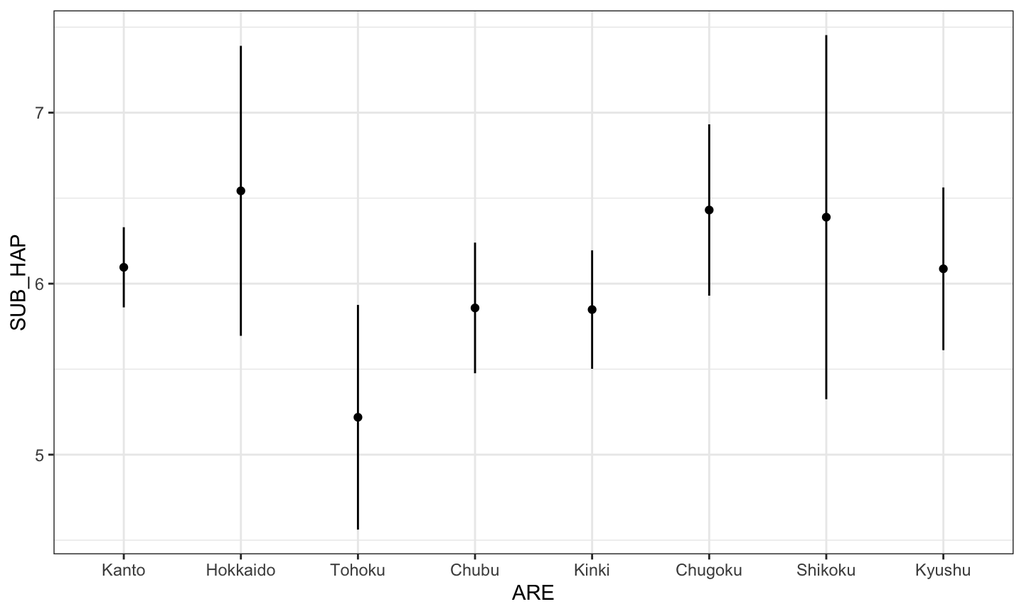

```r
graph
```

このグラフを見る限り，地域ごとに差があるかどうかはわかりません．以前，平均値を算出してみたことがありましたが，今回はそれぞれが「統計的に差がある」ということが言えるかどうかを考えたいと思います．

## 分析をやってみる

さて，分散分析モデルを作成してみましょう．

```r
#"arehap_model"というオブジェクトに，分析モデルを代入する．
arehap_model<-lm(SUB_HAP ~ ARE, data = exdataset)
```

```r
#分析結果の要約を出力する
summary(arehap_model)
```

```
##
## Call:
## lm(formula = SUB_HAP ~ ARE, data = exdataset)
##
## Residuals:
##     Min      1Q  Median      3Q     Max
## -6.5429 -1.4308  0.1515  1.9043  4.7813
##
## Coefficients:
##              Estimate Std. Error t value Pr(>|t|)
## (Intercept)  6.095745   0.120558  50.563  < 2e-16 ***
## AREHokkaido  0.447112   0.413125   1.082  0.27941
## ARETohoku   -0.876995   0.316105  -2.774  0.00564 **
## AREChubu    -0.237637   0.226845  -1.048  0.29510
## AREKinki    -0.247260   0.218299  -1.133  0.25764
## AREChugoku   0.335025   0.314020   1.067  0.28629
## AREShikoku   0.293144   0.564036   0.520  0.60338
## AREKyushu   -0.008788   0.271909  -0.032  0.97422
## ---
## Signif. codes:  0 '***' 0.001 '**' 0.01 '*' 0.05 '.' 0.1 ' ' 1
##
## Residual standard error: 2.338 on 955 degrees of freedom
## Multiple R-squared:  0.01418,    Adjusted R-squared:  0.006954
## F-statistic: 1.962 on 7 and 955 DF,  p-value: 0.05729
```

- 出力結果が入り切らないので`Coefficients`だけ示します．

```
Coefficients:
             Estimate Std. Error t value Pr(>|t|)
(Intercept)  6.095745   0.120558  50.563  < 2e-16 ***
AREHokkaido  0.447112   0.413125   1.082  0.27941
ARETohoku   -0.876995   0.316105  -2.774  0.00564 **
AREChubu    -0.237637   0.226845  -1.048  0.29510
AREKinki    -0.247260   0.218299  -1.133  0.25764
AREChugoku   0.335025   0.314020   1.067  0.28629
AREShikoku   0.293144   0.564036   0.520  0.60338
AREKyushu   -0.008788   0.271909  -0.032  0.97422
```

- \(\alpha\)は`6.095745`である．
- 関東地方と比べて，東北地方の主観的幸福度が低い．
  - 実は昔から言われている結果．
  - 東日本大震災の影響？という声もあったが逆で，東日本大震災によって幸福度が改善したとも言われている．
- その他の地域は影響が認められなかった．

## 分析結果の解釈

- さらに，モデル式による分析結果を出力しました．この結果が示しているのは以下のようなことです．

\[ (主観的幸福度)=0.447112*(北海道)-0.876995*(東北)- \] \[ 0.237637*(中部)-0.247260*(近畿)+ \] \[ 0.335025*(中国)+0.293144*(四国)- \] \[ 0.008788*(九州)+6.095745 + \epsilon_i \]

- 今度はモデル式についても同じように出力してあげましょう．
- 回帰分析やt検定と同じです．

## 分散分析表の出力

```r
#分散分析表
anova(arehap_model)
```

```
## Analysis of Variance Table
##
## Response: SUB_HAP
##            Df Sum Sq Mean Sq F value  Pr(>F)
## ARE         7   75.1 10.7238  1.9623 0.05729 .
## Residuals 955 5218.9  5.4648
## ---
## Signif. codes:  0 '***' 0.001 '**' 0.01 '*' 0.05 '.' 0.1 ' ' 1
```

## 分散分析表の読み方：

```
Analysis of Variance Table
```

- 分散分析表です．分散分析の結果を示しています．

```
Response: SUB_HAP
           Df Sum Sq Mean Sq F value  Pr(>F)
ARE         7   75.1 10.7238  1.9623 0.05729 .
Residuals 955 5218.9  5.4648
```

- `Df`は自由度を示しています．
- `Sum Sq`は平方和
- `Mean Sq`は平均平方
- `F value`はF値
- `Pr(>F)`はp値を示しています．

```
Response: SUB_HAP
           Df Sum Sq Mean Sq F value  Pr(>F)
ARE         7   75.1 10.7238  1.9623 0.05729 .
Residuals 955 5218.9  5.4648
```

- 応答変数は`SUB_HAP`です．
- `ARE`の自由度（分子自由度）は7：全部で8地域ある→N-1が自由度
  - モデル式の\(\beta\)（パラメータ）の数と一致している．
  - `DF`はDegree of Freedom
- `ARE`のF値は1.9623，P値は0.05729
- `Residuals`の自由度（分母自由度）は955：全部で963個のデータがあり，モデル式の\(\beta\)（パラメータ）で7つ，さらにもう1地域（=\(\alpha\)で使われる）を引いたもの．

```
---
Signif. codes:  0 ‘***’ 0.001 ‘**’ 0.01 ‘*’ 0.05 ‘.’ 0.1 ‘ ’ 1
```

- p値の大きさを示す記号．
- 0 -0.001では`***`で表される．
- 0.001-0.01では`**`で表される．
- 0.01-0.05では`*`で表される．
- 0.05-0.1では`.`で表される．
- 0.1-1では何にもありません．

## 書き方

- 主観的幸福度は地域によって異なるかを分析した．その結果，F(7, 955)=1.9623(p< .10)であり，10%水準で有意にあることが示されている．したがって，主観的幸福度は居住地域によって異なる傾向にあることが示されている．
  - 分散分析表を合わせて示してあげましょう．
  - ちなみに，心理学などでは有意水準を5%に設定されることが多い．
  - 経済学系では10%水準を採用することもある．
  - いずれにしろ，分析の前に有意水準を設定する必要がある．

## 結果をきれいに表記しよう．

- パッケージpanderの中にある関数panderを使うと，結果がわかりやすく表示されます．

```r
library(pander)
pander(arehap_model)
```

Fitting linear model: SUB_HAP ~ ARE

|  | Estimate | Std. Error | t value | Pr(>\|t\|) |
| --- | --- | --- | --- | --- |
| **(Intercept)** | 6.096 | 0.1206 | 50.56 | 2.84e-272 |
| **AREHokkaido** | 0.4471 | 0.4131 | 1.082 | 0.2794 |
| **ARETohoku** | -0.877 | 0.3161 | -2.774 | 0.005639 |
| **AREChubu** | -0.2376 | 0.2268 | -1.048 | 0.2951 |
| **AREKinki** | -0.2473 | 0.2183 | -1.133 | 0.2576 |
| **AREChugoku** | 0.335 | 0.314 | 1.067 | 0.2863 |
| **AREShikoku** | 0.2931 | 0.564 | 0.5197 | 0.6034 |
| **AREKyushu** | -0.008788 | 0.2719 | -0.03232 | 0.9742 |

```r
pander(anova(arehap_model))
```

Analysis of Variance Table

|  | Df | Sum Sq | Mean Sq | F value | Pr(>F) |
| --- | --- | --- | --- | --- | --- |
| **ARE** | 7 | 75.07 | 10.72 | 1.962 | 0.05729 |
| **Residuals** | 955 | 5219 | 5.465 | NA | NA |

## 結果をきれいに表記しよう．

- パッケージhuxtableの中にhuxregという関数があります．

```r
library(huxtable)
huxreg(arehap_model)
```

|  | (1) |
| --- | --- |
| (Intercept) | 6.096 *** |
|  | (0.121) |
| AREHokkaido | 0.447 |
|  | (0.413) |
| ARETohoku | -0.877 ** |
|  | (0.316) |
| AREChubu | -0.238 |
|  | (0.227) |
| AREKinki | -0.247 |
|  | (0.218) |
| AREChugoku | 0.335 |
|  | (0.314) |
| AREShikoku | 0.293 |
|  | (0.564) |
| AREKyushu | -0.009 |
|  | (0.272) |
| N | 963 |
| R2 | 0.014 |
| logLik | -2180.170 |
| AIC | 4378.340 |
| *** p < 0.001; ** p < 0.01; * p < 0.05. |  |

## 結果をきれいに表記しよう．

- パッケージcoefplotを使って各係数の大きさをグラフで示す．

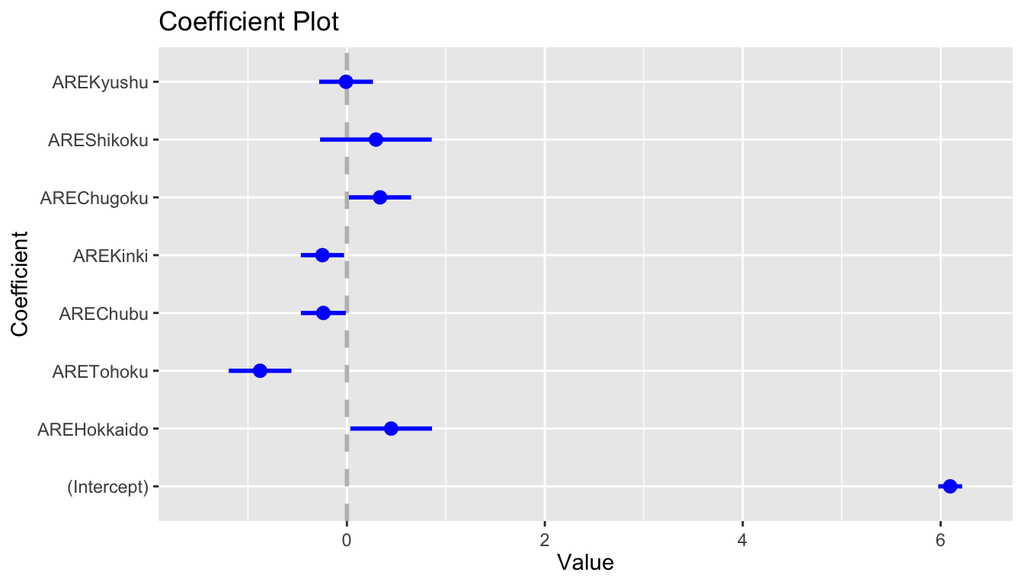

```r
library(coefplot)
coefplot(arehap_model)
```

## 結果をきれいに表記しよう．

- パッケージstargazerの中にあるstargazerという関数を使うとxls形式で出力できます．

```
library(stargazer)
stargazer(arehap_model, type = "html", align=TRUE, title = "分析結果", out = "arehap_model.xls")
```

## 要約

- 一般線形モデルによる分散分析モデル
  - ダミー変数が複数あるような状況を前提とする．

```
    オブジェクト<-lm(応答変数　<-　説明変数, data = データセットの名前)
    これについて，回帰分析／t検定の時は以下のコードを使っています．
    summary(オブジェクト)
    これについて，分散分析の時は以下のコードを使っています．
    anova(オブジェクト)
```

## 分散分析モデルと呼ばれる由縁

- 通常，説明変数および応答変数が数値データであった場合には「回帰分析」を，説明変数が因子データ，応答変数が数値データの時は「分散分析」を用いることが基本でした．
  - 回帰分析：説明変数によって応答変数がどのように変化するのか推定値を求める．
  - 分散分析：説明変数によって，応答変数の差異が異なるかどうかを求める．
- しかし，昨今では一般線形モデルの枠組みの中から，回帰分析と同様にある因子データのような要因の影響を明らかにするような手法が用いられるようになりました．
- この授業では，説明変数が因子データの場合を分散分析モデルと呼んでいます．

## 2要因分散分析モデル(交互作用あり)

## 2要因分散分析(交互作用あり)

- 続いて，2要因分散分析に進みたいと思います．2要因分散分析とは，複数の要因による影響を分析するものです．例えば，主観的幸福度は子の有無(1,0のダミー変数)だけでなく，結婚しているか否か(1, 0のダミー変数)によっても影響を受ける可能性があります．これを用いると「子がいない未婚者」「子がいない既婚者」「子がいる未婚者」「子がいる既婚者」の計4つの状態があります．
- したがって，これらが影響を与えているかどうかを明らかにするために，いずれの要因についても投入したモデル式について考えたいと思います．ここでは，次のようなモデル式を考えたいと思います．

\[Y_i=\beta_1 X_1 +\beta_2 X_2 +\beta_3 X_1* X_2 + \alpha+\epsilon_i \]

このモデル式によって，「4つの状態」を分析することができます．一度整理してみましょう．

- \(X_1 =1\)と\(X_2 =0\)の場合  
  \[Y_i=\beta_1 X_1+\alpha+\epsilon_i\]
  - この場合，ある因子\(X_1\) によって，傾きが変化することを示しています．
  - ex.子がいない独身者よりも，子がいる独身者の方が幸せとか
- \(X_1 =0\)と\(X_2 =1\)の場合  
  \[ Y_i=\beta_2 X_2 + \alpha+\epsilon_i \]
  - この場合，ある因子\(X_2\) によって，傾きが変化することを示しています．
  - ex.子がいない未婚者よりも，子がいない既婚者の方が幸せとか
- \(X_1 =1とX_2 =1\)の場合  
  \[Y_i= \beta_1 X_1 +\beta_2 X_2 +\beta_3 X_1* X_2 + \alpha+\epsilon_i \]
  - この場合，\(X_1\) と\(X_2\) が影響する場合の値を示していることになります．特に，\(X_1* X_2\) の係数が有意になる場合は単純に\(X_1\) と\(X_2\) が同じように影響を与えているだけでなく，組み合わさることによって効果が強まることを示しています．
  - 「組み合わさることにより効果が変化する」ことを「交互作用」といいます．
  - ex.子がいない未婚者よりも，子がいる既婚者の方が幸せとか
- \(X_1 =0とX_2 =0\)の場合 \[ Y_i= \alpha+\epsilon_i \]
- この場合，全ての要因が影響しない場合（何らかの基準となる点）の値を示していることになります．
  - ex.子がいない未婚者の幸福度の推定値

## 仮説を立てる

さて，それでは仮説を立ててみましょう．今回分析するテーマは「主観的幸福度(SUB_HAP)が子の有無(CHI)と結婚(MAR)によって異なる」かどうかを分析します．二要因分散分析（交互作用有り）の場合は以下のような仮説を立てます．

```
* 対立仮説：主観的幸福度の平均値は結婚かつ子の有無によって異なる．
* 帰無仮説：主観的幸福度の平均値は結婚かつ子の有無によって異なるとは言えない．
```

## 平均値をプロットする

さて，最初のお約束です．平均値をプロットしましょう． まずは各自でやってみましょう．

さて，例によってggplotguiを使いましょう．

以下のコードはConsole（コンソール）に直接打ち込みます．

```
library(ggplotgui)
ggplot_shiny(exdataset)
```

そうすると新しいウィンドウが開きます．

以下の通りの作業をしましょう．

- ggplotタブへ
- “*Type of graph:*”は“*Dot + Error*”，Y-variableは“*SUB_HAP*”，X-variableは“*MAR*”を設定
- “Group(or colour)”を*CHI*に変更
- “*Confidence Interval:*”を95%にする．
- R-codeタブへ行って，以下のコードのうち，真ん中のみを以下にする． -また，コード内の*df*を*exdataset*に変える．

```r
# You need the following package(s):
library("ggplot2")

# The code below will generate the graph:
graph <- ggplot(exdataset, aes(x = MAR, y = SUB_HAP, colour = CHI)) +
  geom_point(stat = 'summary', fun.y = 'mean') +
  geom_errorbar(stat = 'summary', fun.data = 'mean_se',
                width=0, fun.args = list(mult = 1.96)) +
  theme_bw()
```

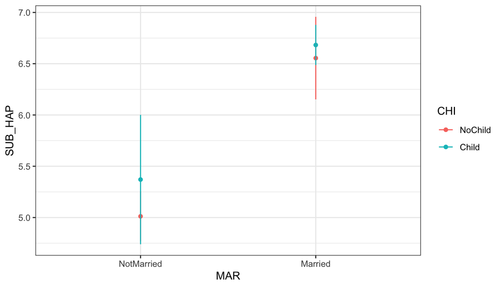

```r
graph
```

このグラフを見る限り，未婚者に比べて既婚者の方が主観的幸福度が高そうですが，子の有無の影響はありそうな気もしますし，なさそうな気もしますし何とも言えません．したがって，この点についても統計的に差があるのかどうかを明らかにしましょう．

```r
marchihap_model <-lm(SUB_HAP ~ MAR*CHI, data = exdataset)
#モデル式をMARCHIHAP_modelというオブジェクトにしまいます．
```

```r
#分析結果の要約を出力する
summary(marchihap_model)
```

```
##
## Call:
## lm(formula = SUB_HAP ~ MAR * CHI, data = exdataset)
##
## Residuals:
##     Min      1Q  Median      3Q     Max
## -6.6825 -1.6825  0.3175  1.3175  4.9882
##
## Coefficients:
##                     Estimate Std. Error t value Pr(>|t|)
## (Intercept)           5.0118     0.1200  41.763  < 2e-16 ***
## MARMarried            1.5429     0.2295   6.724 3.03e-11 ***
## CHIChild              0.3586     0.3242   1.106    0.269
## MARMarried:CHIChild  -0.2308     0.3930  -0.587    0.557
## ---
## Signif. codes:  0 '***' 0.001 '**' 0.01 '*' 0.05 '.' 0.1 ' ' 1
##
## Residual standard error: 2.213 on 959 degrees of freedom
## Multiple R-squared:  0.113,  Adjusted R-squared:  0.1102
## F-statistic: 40.73 on 3 and 959 DF,  p-value: < 2.2e-16
```

## 結果の書き方

この分散分析表の結果より以下のように結果を導き出すことが出来ます． 交互作用のある分散分析により，主観的幸福度は結婚および子の有無によって異なるかを分析した．その結果，結婚についてはF(1, 959)=120.63(p< .001)であり，結婚が主観的幸福度に対して有意に影響を与えていることが明らかとなった．一方，子の有無についてはF(1, 959)=1.2102(p> .05)，結婚と子の有無の交互作用についてはF(1, 959)=0.3448(p> .05)であり，有意差は認められなかった．

## 結果の解釈

この結果は以下のように解釈することが出来ます．

\[(主観的幸福度)=1.543(結婚)+0.359(子ども)-\] \[0.231(結婚×子ども)+5.012\]

ただし，以下のように変数を割り振っています．

- 結婚：未婚→0，既婚→1
- 子ども：子なし→0，子あり→1

したがって，「未婚者かつ子なし」「未婚者かつ子あり」「既婚者かつ子なし」「既婚者かつ子あり」という4つのありえる状態について，次のように主観的幸福度を推定することが出来ます．

## 結果の解釈

- 「未婚者かつ子なし」 \[(主観的幸福度)=1.543×0+0.359×0-0.231(0×0)+5.012\] \[(主観的幸福度)=5.012\]
- 「未婚者かつ子あり」 \[(主観的幸福度)=1.543×0+0.359×1-0.231(0×1)+5.012\] \[(主観的幸福度)=0.359+5.012=5.371\]
- 「既婚者かつ子なし」 \[(主観的幸福度)=1.543×1+0.359×0-0.231(1×0)+5.012\] \[(主観的幸福度)=1.543+5.012=6.555\]
- 「既婚者かつ子あり」 \[(主観的幸福度)=1.543×1+0.359×1-0.231(1×1)+5.012\] \[(主観的幸福度)=1.543+0.359-0.231+5.012=6.683\]

ここから，未婚者に比べて既婚者の主観的幸福度が高いことはわかりますが，子の有無は主観的幸福度に対して影響をどうも与えなそうです．

## 結果をきれいに表記しよう．

- パッケージpanderの中にある関数panderを使うと，結果がわかりやすく表示されます．

```r
library(pander)
pander(marchihap_model)
```

Fitting linear model: SUB_HAP ~ MAR * CHI

|  | Estimate | Std. Error | t value | Pr(>\|t\|) |
| --- | --- | --- | --- | --- |
| **(Intercept)** | 5.012 | 0.12 | 41.76 | 5.108e-218 |
| **MARMarried** | 1.543 | 0.2295 | 6.724 | 3.034e-11 |
| **CHIChild** | 0.3586 | 0.3242 | 1.106 | 0.2689 |
| **MARMarried:CHIChild** | -0.2308 | 0.393 | -0.5872 | 0.5572 |

```r
pander(anova(marchihap_model))
```

Analysis of Variance Table

|  | Df | Sum Sq | Mean Sq | F value | Pr(>F) |
| --- | --- | --- | --- | --- | --- |
| **MAR** | 1 | 590.7 | 590.7 | 120.6 | 1.622e-26 |
| **CHI** | 1 | 5.926 | 5.926 | 1.21 | 0.2716 |
| **MAR:CHI** | 1 | 1.688 | 1.688 | 0.3448 | 0.5572 |
| **Residuals** | 959 | 4696 | 4.896 | NA | NA |

## 結果をきれいに表記しよう．

- パッケージhuxtableの中にhuxregという関数があります．

```r
library(huxtable)
huxreg(marchihap_model)
```

|  | (1) |
| --- | --- |
| (Intercept) | 5.012 *** |
|  | (0.120) |
| MARMarried | 1.543 *** |
|  | (0.229) |
| CHIChild | 0.359 |
|  | (0.324) |
| MARMarried:CHIChild | -0.231 |
|  | (0.393) |
| N | 963 |
| R2 | 0.113 |
| logLik | -2129.304 |
| AIC | 4268.608 |
| *** p < 0.001; ** p < 0.01; * p < 0.05. |  |

## 結果をきれいに表記しよう．

- パッケージcoefplotを使って各係数の大きさをグラフで示す．

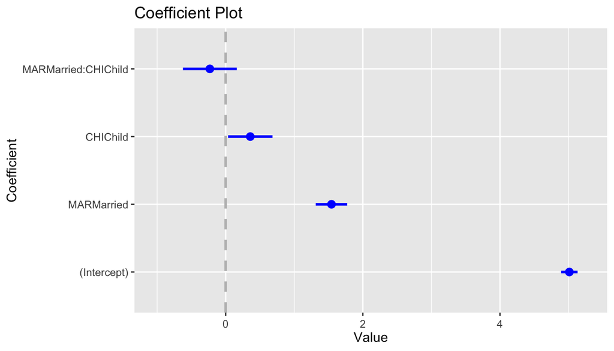

```r
library(coefplot)
coefplot(marchihap_model)
```

## 結果をきれいに表記しよう．

- パッケージstargazerの中にあるstargazerという関数を使うとxls形式で出力できます．

```
library(stargazer)
stargazer(marchihap_model, type = "html", align=TRUE, title = "分析結果", out = "marchihap_model.xls")
```

## 分散分析（一般線形モデルによる分散分析モデルによる分析）

- 一般線形モデルによる分散分析モデル
  - ダミー変数が複数あるような状況を前提とする．
- 交互作用ありモデル：
  - 組み合わせによってパワーパップorパワーダウン．．．

```
    オブジェクト<-lm(応答変数　<-　説明変数, data = データセットの名前)
    これについて，回帰分析／t検定の時は以下のコードを使っています．
    summary(オブジェクト)
    これについて，分散分析の時は以下のコードを使っています．
    anova(オブジェクト)
```

## jamoviでの演習

## jamoviでの演習

- 2要因分散分析（交互作用ありモデル）
  - 平均値のプロット
  - モデルの構築
  - 結果の出力

## 演習問題

## 演習問題1

“SUB_HAP”は主観的幸福度，“SUB_SAT”は生活満足度，“SUB_SLP”は睡眠満足度に関するデータであった（各10点尺度）．これらを応答変数，性別を表す“F_SEX”及び結婚を示す“MAR”(0:未婚，1:既婚)を説明変数として，以下の3つの「交互作用あり」の分析を実施せよ．それぞれについてグラフ，分散分析表とモデルの結果を出力すること．

- 主観的幸福度の性別差（男女その他）および既婚・未婚の影響を分析せよ．
- 生活満足度の性別差（男女その他）および既婚・未婚の影響を分析せよ．
- 睡眠満足度の性別差（男女その他）および既婚・未婚の影響を分析せよ．

## 演習問題2（余裕があればやってみること）

応用：もし，可能であればこちらについても挑戦すること．子の有無は“CHI”(0:子なし，1:子あり)で示されている．

- 主観的幸福度の性別差（男女その他）および既婚・未婚と子の有無の影響を分析せよ．
- 生活満足度の性別差（男女その他）および既婚・未婚と子の有無の影響を分析せよ．
- 睡眠満足度の性別差（男女その他）および既婚・未婚と子の有無の影響を分析せよ．